# Assignment 3: Dissipative Particle Dynamics

**6EMA02 Particle-based Simulations, 2026-2027 edition** Mesoscale simulation · soft repulsive beads · demixing and interfaces

## How this assignment is assessed: read this first

This notebook is both the assignment text and your report. Task cells (like this one) are the assignment text and are marked read-only. Jupyter enforces that; some editors (VS Code among them) do not, so simply leave them untouched either way: hand-ins are checked against the released notebook, and modified task cells are flagged. You write your answers in the cells below each task and hand in this same notebook, **executed**, together with an HTML export, your code, and the data files the notebook loads (layout at the end of this notebook).

Your report is **not graded on its content**. Its result is determined in the individual oral examination at the end of the quartile: the exam is a conversation about *your* code and *your* results, with this notebook on screen. Write it as your defence dossier: concise, bullet answers are fine, every claim something you can stand behind. A report you never hand in scores 0 for its weight in the final grade; a handed-in report's result *is* your oral grade.

**AI and sources.** You may use AI assistants (ChatGPT, Claude, Copilot, …) freely in this course, for code, analysis, and text. Declare the use briefly in the *Sources* section below, along with any other external sources: anything in your submission (code, text, data, results) that your group did not produce itself. Declared sources are never penalised: nobody grades the text of your report or the style of your code. The oral examination assesses what *you* understand about the simulation you hand in. Anything in your submission is fair game, and "we didn't write that part" is not an available answer. Presenting undeclared external work as your own is academic misconduct and is treated as such.

## Group

- **Group ID:** A3_6
- **Members:** Jacob (Job) Scheepens (2364654), Tomas Dadikozyan (1959123)

## The physics: why a mesoscale method exists

Your A2 code integrates the motion of individual molecular sites with a time step of about a femtosecond. Now consider what you would need to simulate a droplet of oil in water demixing, or a polymer solution flowing through a channel: micrometres of space and microseconds of time. That is roughly $1012$ sites and $109$ steps. Molecular dynamics cannot get there, and continuum fluid mechanics cannot resolve the individual polymer chains that matter. **Dissipative particle dynamics (DPD) lives in that gap.**

The trick is **coarse-graining**. One DPD bead is not an atom: it stands for a lump of fluid, a cluster of molecules moving together. Because a bead is a soft blob rather than a hard molecule, two beads may overlap, and the repulsion between them is **soft**:

$$𝐅ijC=aij(1−rijrc)𝐫^ijfor rij<rc,$$

finite even at $rij=0$. No $r−12$ wall means no violently fast collisions, which is what buys the very large time steps that make the method useful.

Coarse-graining throws away degrees of freedom, and they must come back as noise and friction. DPD adds two more pair forces:

$$𝐅ijD=−γωD(rij)(𝐫^ij·𝐯ij)𝐫^ij,𝐅ijR=σωR(rij)ζijΔt𝐫^ij.$$

The dissipative force damps the *relative* velocity of a pair, the random force kicks it. Neither is arbitrary: the **fluctuation-dissipation theorem** ties their amplitudes and their weight functions together (Eq. (5) of the paper, with $ωD=[ωR]2$ and $σ2=2γkBT$). Get that relation wrong and your system simply equilibrates to the wrong temperature, which is exactly what task B3 checks.

The decisive property is that **all three forces act pairwise along the line between beads**, so they conserve momentum. That is the difference between DPD and Brownian or Langevin dynamics, where the friction is with an implicit background that absorbs momentum. Conserved momentum means the correct long-wavelength behaviour emerges by itself: DPD reproduces hydrodynamics, so a DPD fluid flows, carries shear, and mediates hydrodynamic interactions between suspended objects. That is what makes it a *mesoscale* method rather than a fast approximation.

What does a bead stand for, quantitatively? Groot and Warren fix that by matching the compressibility of water at $ρ=3$, giving $aii≈25kBT/rc$ for beads of the same type. Different types repel more strongly, $aij>aii$, and the excess drives demixing. The link to polymer physics is the Flory-Huggins parameter $χ$, which you will measure in task C3 and which turns out to depend linearly on $Δa=aAB−aAA$. Add springs between beads and you have polymer chains, whose demixing at much smaller $Δa$ (the $χN$ of Eq. (27)) is the subject of Part D.

## What you will do, and the reference paper

You will convert **your own MD code from Assignment 2** into a DPD code, verify it, and then use it to reproduce published results. There is no new starting code for A3, and so no `\todo` list to guide you: everything you have to build is stated in this notebook, in the section *From your A2 code to a DPD code* below and in the task texts. Read both before you change a line.

The reference is Groot and Warren, *J. Chem. Phys.* **107**, 4423 (1997), handed out under Files ▸ Papers. Equation and figure numbers in this notebook refer to that paper. Reproducing a published result is the strongest form of validation available to you here: the numbers exist independently of your code, so agreement is evidence and disagreement is information.

**Units: not the units of A2.** In A2 the energy unit was $kB×1$ K, lengths were in Å and masses in amu, so $kBT=293$, the masses were about 15, the cut-off was 14 and the time step 0.001 (about 1 fs). DPD uses its own reduced units: the cut-off distance $rc$ of the DPD interactions is the unit of length, the bead mass $m$ the unit of mass, and the thermal energy $kBT$ the unit of energy. The time unit follows as $rcm/kBT$. So $rc=m=kBT=1$, and **every number in your A2 `setparameters.c` changes**; the table in the next section lists them. Report everything in these units unless you say otherwise.

**The integrator stays.** Groot and Warren's Eq. (9) is a velocity-Verlet step in which the velocity-dependent forces of the new time step are evaluated with a predicted velocity $𝐯~=𝐯(t)+λΔt𝐟(t)/m$. Your A2 loop already does this with $λ=1/2$: it calls `calculate_forces` after the first half kick and the position update, so the velocities the force routine sees are exactly $𝐯(t)+12Δt𝐟(t)/m$. Keep the loop as it is. Use $Δt=0.04$ for all thermostatted runs, as the paper does.

Expect the conversion to be where the bugs are. Take small steps, run a short simulation after each change, and look at it in OVITO before you measure anything.

**Your working environment** is the one you set up for A1 and A2: the `pbs-env` environment from `requirements.txt`, `nb2html.py` for the HTML you hand in, and `check_my_submission.py` before you submit. See the Canvas page *Working on the assignments*.

## From your A2 code to a DPD code

This is the inventory: what you can keep, what you must change, and what you must write from nothing. Names refer to the A2 starting code; if you renamed things in A2, map them onto your own.

**Keep as it is.** The velocity-Verlet loop in `main.c` and the two routines in `dynamics.c` it calls (`update_velocities_half_dt`, `update_positions`); `boundary_conditions`; the cell list and neighbour list in `nbrlist.c`; `v3_min_image` and the other vector helpers; the restart files; the bond list built in `initialise_bond_connectivity` and `initialise_structure`; and the finite-difference force test. The test still works for the conservative force and the springs, which derive from a potential, provided you switch the dissipative and random forces off while it runs; it cannot test those two, which derive from no potential.

**Change.**

| A2 | A3 |
| --- | --- |
| $kBT=293$, masses 15.035 and 14.027 | $kBT=1$, both masses 1 |
| `r_cut = 14`, `r_shell = 1` | `r_cut = 1`, `r_shell` about 0.3 to 0.4 |
| `dt = 1e-3` | `dt = 0.04` (task B1 uses smaller values) |
| cubic box from the mass density | box in units of $rc$, `num_part` $=ρLxLyLz$ with $ρ=3$ (see the run plan) |
| Lennard-Jones $ϵij$, $σij$ per type pair | DPD repulsion $aij$ per type pair; two types, A and B |
| bond $12kb(r−r0)2$, $r0=1.54$ | the same routine with $r0=0$ and $kb=C=2$: that *is* Eq. (25) |
| angle and torsion terms | **removed**: delete their calls from `calculate_forces`. `initialise_structure` derives angles and dihedrals from the bonds by itself, so leaving the calls in applies pentane angle and torsion forces … |
| `factor_12_nb = factor_13_nb = factor_14_nb = 0` | **all three equal to 1**: in DPD bonded beads also repel each other (task A2) |
| CH$3$ and CH$2$ in fixed pentane order | type A or B per chain, a chosen fraction of each (task A2) |
| 5 sites per molecule, 4 bonds | chains of $N$ beads, $N−1$ bonds; $N=1$ means no bonds at all |
| pentanes on a lattice | random-walk chains, optionally A and B in separate halves of the box (task A2, Part C) |
| Berendsen thermostat, `is_NVT = 1` | **removed**: the dissipative and random forces are the thermostat, and rescaling the velocities on top of them destroys the fluctuation-dissipation balance they rely on |
| output and sampling intervals, in steps | check each one: a step is now $0.04$ time units, not 1 fs |
| `record_trajectories_pdb` labels every site C | OVITO then sees one particle type. If your A beads come first, colour by index: *Expression selection* with `ParticleIndex <` (number of A beads), then *Assign color*. Otherwise write the type into th… |

**Write new.**

- The three DPD pair forces in `calculate_forces_nb` (task A1). They need the velocities and the time step, which the Lennard-Jones loop never used, and a source of random numbers.
- Two switches in `setparameters.c`, one for the conservative force and one for the dissipative and random forces together. Part B runs with each of them off in turn.
- On-the-fly analysis, most of it new: $g(r)$ per type pair (A3); the velocity distribution (B3), which you may already have from A2; the composition profile along $x$ (Part C); the diagonal components of the pressure tensor (C4); the end-to-end distance of the chains (D1).

## The runs, at a glance

Every run is a separate compilation with its own `setparameters.c` values, as in A2. Density $ρ=3$ throughout and $aAA=aBB=25$; $Δa=aAB−25$. The step counts are a suggestion that is known to be enough. For orientation, a reference DPD code of the same structure as yours does 60 000 steps of 6000 beads in about five minutes on one core.

| runs | box | beads | $N$ | $aAB$ | switches, $Δt$ | steps | tasks |
| --- | --- | --- | --- | --- | --- | --- | --- |
| energy | $103$ | 3000 | 1 | 25 | dissipative and random **off**; $Δt$ = 0.04, 0.02, 0.01, 0.005; start from the end of the monomer-fluid run | to $t=200$ | B1 |
| ideal gas | $103$ | 3000 | 1 | 25 | conservative **off** | 20 000 | B2, B3 |
| monomer fluid | $103$ | 3000 | 1 | 25 | all on | 20 000 | B3, C1 |
| Fig. 6 | $20×10×10$ | 6000 | 1 | 37 | all on, separated start | 60 000 | C2 |
| χ series | $20×10×10$ | 6000 | 1 | 35, 39, 43, 47 | all on, separated start | 60 000 each | C3, C4 |
| control | $20×10×10$ | 6000 | 1 | 25 | all on, separated start | 60 000 | C4 |
| chains | $103$ | 3000 | 5 | 25 | all on | 20 000 | D1 |
| chain demixing | $20×10×10$ | 6000 | 3, 5, 10 | 28 | all on, separated start | 60 000 each | D2, D3 |
| chain χ series | $20×10×10$ | 6000 | 3; 5; 10 | 30, 32; 27, 28.5, 30; 26, 26.5, 27 | all on, separated start | 60 000 each | D3 |

Long runs are done in the terminal, never from the notebook; let the notebook load their output from `data/`.

## Code map: fill in as you go

The examiner uses this table in the oral to jump straight to your code, so the entries are clickable links with paths relative to this notebook (`code/…`, `data/…`); everything linked is inside the zip.

| Task | File / function(s) | Data files |
| --- | --- | --- |
| A1 DPD forces | `calculate_forces_nb`, `gauss`, σ in `set_parameters` | B3_velocity_on_velocity_stats.csv |
| A2 bead-spring chains, initialisation | `initialise_bond_connectivity`, `initialise_types`, `initialise_positions`, `calculate_forces_bond` | D1_chain_snapshot.pdb |
| A3 g(r) | `sample_rdf`, `analysis_write` | B2_rdf_ideal_gas.csv |
| B1 energy conservation | `update_velocities_half_dt`, `update_positions`, `calculate_forces_nb`, `run_b1.sh` | B1_004.csv, B1_002.csv, B1_001.csv, B1_0005.csv |
| C1 g(r) with blocks | `sample_rdf`, `write_rdf_block` | C1_a25_rdf_blocks.csv |
| C2/C3 composition profile, χ | `sample_profile`, `write_profile_block`, `render_ovito.py` | C2_a37_profile.csv, C2_ovito_snapshot.png, C3_a35_profile.csv |
| C4 pressure tensor, surface tension | `calculate_forces_nb`, `calculate_forces_bond`, `update_velocities_half_dt`, `sample_pressure` | C4_a25_pressure.csv, C2_a37_pressure.csv |
| B2/B3 ideal gas, velocities | `sample_rdf`, `sample_velocity`, `write_velocity_histogram` | B2_rdf_ideal_gas.csv, B3_velocity_off_velocity_hist.csv, B3_velocity_on_velocity_hist.csv |
| D1 chain size | `sample_chain_size` | D1_chain_size.csv, D1_chain_snapshot.pdb |
| D2 chain demixing | `sample_composition_profile`, `write_composition_profile_block` | D2_N3_composition.csv, D2_N5_composition.csv, D2_N10_composition.csv, D2_composition_profiles.png |
| D3 χ for chains | `sample_profile`, `write_profile_block`, `run_c.sh` | D3_N5_da3.5_profile.csv (one file per run, see the table in the build log) |

## Sources

**AI tools used:** Claude Code (Anthropic, Claude Sonnet 5.5).

**Used for:**

- the Part C and D3 code: per-axis pressure tensor (`forces.c`, `dynamics.c`), block-wise g(r), composition profile and pressure series (`analysis.c`), and the run script `code/run_c.sh`;
- the analysis cells and written answers for C1 to C4 and D3, the code map, the build and run log, the regenerated B1 data (`code/run_b1.sh`), the OVITO rendering script (`code/render_ovito.py`), and a fix of the B2 plot cell (it now reads `B2_rdf_ideal_gas.csv`).

**Other external sources:**

- R. D. Groot and P. B. Warren, *J. Chem. Phys.* **107**, 4423 (1997): equations (18), (24), (27), (31), (36) and the comparison values (Fig. 2 read off by eye, slopes 0.286 and 0.306).
- The course starting code (A2) is the basis of `code/`.

## Build & run log

**Machine and build.** Windows 11, 20 cores, gcc 14.2 (MSYS2 ucrt64). Everything is configured in `code/setparameters.c`, so each run is a separate compilation: `gcc -O3 code/*.c -o dpd -lm`, run from `Assignment_3/` as `./dpd > run.csv`.

**Parts A and B and D1** (single runs, set by hand in `setparameters.c`; wall-clock times were not recorded, each takes seconds to a few minutes):

| data | settings |
| --- | --- |
| `B1_004`, `B1_002`, `B1_001`, `B1_0005` | `bash code/run_b1.sh` (20 s): dissipative and random force off, $N=1$, $a=25$, box $103$, start from the end state of the C1 run (so C1 must be run first); $Δt$ = 0.04 / 0.02 / 0.01 / 0.005, 200 / 400… |
| `B2_rdf_ideal_gas` | conservative force off, $a=25$, box $103$, $Δt=0.04$, 20 000 steps, g(r) on |
| `B3_velocity_off_*`, `B3_velocity_on_*` | all forces on (conservative off for `off`), same box, 20 000 steps, velocity analysis on |
| `D1_chain_size`, `D1_chain_snapshot.pdb` | $N=5$, $a=25$ for all pairs, box $103$, 20 000 steps, chain-size analysis on |
| `D2_N<N>_composition` | $N$ = 3, 5, 10, box $20×10×10$, $aAB=28$, demixed start, 60 000 steps, one build per $N$ (profiles averaged in the D2 cell from `D2_N<N>.pdb`, not handed in) |

**Parts C and D3** (all production runs from one script, in parallel, from `Assignment_3/`):

```
export PATH=/c/msys64/ucrt64/bin:$PATH       # gcc for bash on Windows
bash code/run_c.sh                            # C1, C2, C3 (4 runs) and C4
RUNS="D3_N3_da3 D3_N3_da5 D3_N3_da7 D3_N5_da2 D3_N5_da3.5 D3_N5_da5 D3_N10_da1 D3_N10_da1.5 D3_N10_da2" bash code/run_c.sh
```

The script builds each run in `build_c/<run>/` from a patched copy of `setparameters.c`. Common settings: $Δt=0.04$, $γ=4.5$, $rshell=0.4$, $ρ=3$, fresh start. Profiles are written per block of 5000 steps (bin 0.25), the pressure tensor every 10 steps.

| runs | box, beads | $N$ | $aAB$ | start | steps | wall-clock (all runs of a row in parallel) |
| --- | --- | --- | --- | --- | --- | --- |
| C1 | $103$, 3000 | 1 | 25 | mixed | 20 000 | 3 min |
| C2 | $20×10×10$, 6000 | 1 | 37 | separated | 60 000 | about 10 min with C3 and C4 |
| C3 | same | 1 | 35, 39, 43, 47 | separated | 60 000 | (same batch) |
| C4 control | same | 1 | 25 | separated | 60 000 | (same batch) |
| D3 | same | 3, 5, 10 | 25 + $Δa$ (see script) | separated | 60 000 | 23 min for all nine |

Output goes to `data/<run>_profile.csv`, `_pressure.csv`, `_rdf_blocks.csv` and `_traj.pdb`. The run names `D3_N<N>_da<Δa>` give $N$ and $Δa$.

**OVITO snapshot of C2:** `python code/render_ovito.py data/C2_a37_traj.pdb data/C2_ovito_snapshot.png` (needs `pip install ovito`; renders the last frame, A red and B blue).

## Part A: Implementing the DPD method

*In the oral you should be able to:* explain each of the three DPD pair forces and what it does to the system's energy and momentum; explain the $1/Δt$ in the random force; explain why σ and γ are not independent, and why the Berendsen thermostat had to go.

### A1) DPD pair forces

Replace the Lennard-Jones interaction in `calculate_forces_nb` by the DPD pair forces of Eqs. (3), (4) and (8): the conservative force $𝐅C$, the dissipative force $𝐅D$, and the random force $𝐅R$, with the weight functions of Eq. (6) and all three zero beyond $rc$. Use $γ=4.5$ and derive $σ$ from the fluctuation-dissipation relation, Eq. (5). For the random force use $ζij$ with mean zero and variance 1; uniformly distributed numbers from $[−3,3]$ are recommended (see the discussion on p. 4426 of the paper). Make the conservative force type-dependent, $aij$ per pair of types, stored the way A2 stored $ϵij$.

The potential energy your routine returns is that of the conservative force alone: the other two derive from no potential. Accumulate the virial from the conservative force only, as in the second line of Eq. (15).

Document in the cell below: the value of $σ$ you derived and from which relation; how you ensured that $ζij=ζji$ for a pair (what would break if it were not?); and where in your step the random force is drawn, given that it depends on $Δt$.

*Implementation notes (A1):*

$σ=2γkbT$

$ζij=ζji$ is ensured by implementing the gaussian only once per pair in the neighbour list and uses that same force for both particles.

The random force is drawn after the positions and boundary consitions are updated, but before the second half-step velocity update.

### A2) Bead-spring chains

Adapt the code to chains of $N$ beads: `initialise_bond_connectivity` must bond bead $k$ to bead $k+1$ within each chain, and `initialise_types` must give all beads of a chain the same type, A or B. The spring force between bonded beads is

$$𝐟ij=−C𝐫ij,C=2kBTrc−2$$

(note the sign error in the paper's Eq. (25); the spring is always attractive). This is your A2 bond force with rest length zero.

Bonded pairs must **also** interact through the DPD pair forces. In A2 the excluded pairs would have overlapped the steep Lennard-Jones core, and the bonded terms already described their interaction. Neither holds here: the DPD repulsion is soft, and a chain bead is the same bead as a monomer, with the same repulsion from every neighbour. In the A2 code that means setting `factor_12_nb`, `factor_13_nb` and `factor_14_nb` to **one**, the opposite of A2: a factor zero excludes a pair, and a factor one treats it like any other pair (and skips the connectivity lookup altogether).

Write an initialisation for chain systems that avoids overstretched springs, for instance each chain as a random walk with steps of about the mean bond length. Give it an option to start all A chains in the half $x<Lx/2$ and all B chains in $x>Lx/2$, which every demixing run of Parts C and D uses.

Document your initialisation, and state what would go wrong physically if 1-2 and 1-3 pairs *were* excluded here, given that this is the opposite of what you did in A2.

*Implementation notes (A2):*

**Initialisation** (`initialise_types`, `initialise_bond_connectivity`, `initialise_positions`, `initialise_velocities` in `code/initialise.c`):

- *Types and bonds.* Chain $m$ is type A if $m$ is even and type B if it is odd, so there are equal numbers of A and B chains and all beads of a chain have the same type. Bead $k$ is bonded to bead $k+1$ within a chain ($N−1$ bonds per chain, none for $N=1$).
- *Chains as random walks.* The first bead of a chain is put at a random position. Each next bead is placed at the fixed distance $req=a/(a+C)=25/27=0.93$ from the previous one, in a random direction (uniform on the sphere). This is the distance at which the spring force $Cr$ balances the repulsion $a(1−r)$, so the springs start almost unstretched, and it is close to the maximum of $g(r)$ (C1).
- *Overlaps.* A chain is redrawn if one of its beads comes closer than $0.5req$ to a bead that is already placed (at most 100 000 tries per chain). The repulsion is soft, so this only prevents beads from starting on top of each other.
- *Demixed start* (`demix_initialisation = 1`). All beads of an A chain must lie in $x<Lx/2$ and all beads of a B chain in $x>Lx/2$, after periodic wrapping. This gives two flat interfaces perpendicular to $x$ (every demixing run of C and D).
- *Velocities.* Maxwell-Boltzmann with variance $kBT/m$ per component, with the centre-of-mass velocity removed.
- The structure is not equilibrated separately: the run itself does it, and the first part of each run is discarded in the analysis.

Demixed Initialization: (chain length = 5, not easily seen in OVITO)

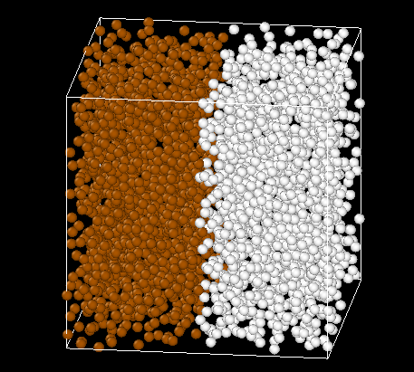

Normal Initialization: (chain length = 5, not easily seen in OVITO)

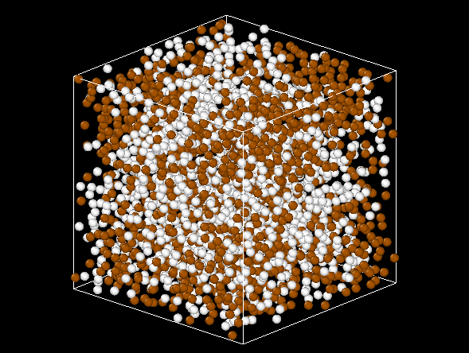

**What would go wrong if the 1-2 and 1-3 pairs were excluded.** In A2 exclusion was right: the Lennard-Jones core is steep, and the bond and angle terms described how neighbours in a molecule interact. Here the springs have rest length 0 and are only attractive, and the *only* thing that keeps bonded beads apart is the soft DPD repulsion. Without it:

- the chains would follow the springs alone, i.e. be ideal chains with $⟨R2⟩=3(N−1)kBT/C$ (6 for $N=5$) and too compact; with the repulsion, as we have it, D1 gives 6.75;
- the dissipative and random forces between bonded neighbours would be missing, so their relative motion would not be thermostatted directly;
- the chain beads would no longer behave like monomer beads. The mapping of $χ$ onto $Δa$ (Eq. 23) assumes that every pair of beads within $rc$ interacts in the same way, whatever the connectivity.

### A3) Radial distribution function

Implement on-the-fly calculation of the radial distribution function $g(r)$, per type pair (AA, AB, BB), up to $r=3$. State your bin width and the normalisation you used, and how you convinced yourself the normalisation is right (a run whose answer you know in advance is the cheapest way; task B2 gives you one).

*Implementation notes (A3):*

The bin width used is 0.05, which gives 60 bins between r=0 and r=3. In each bin the code counts pairs which minimum-image distance falls between r=0 and r=3 and then compares the count with the expected number is they would be uniformly distributed in the box.

The g(r) function is then checked using the B2 run.

## Part B: Verification for monomers (N = 1)

*In the oral you should be able to:* say which bug classes each of these three tests isolates, and why together they cover the code; derive the conservative pair potential; explain why the energy-conservation run needs a smaller timestep than a thermostatted run.

These three tests are designed to be run with parts of the physics switched off, which is what makes them sharp: each isolates one layer of the implementation. All three use the cubic box of side 10 with 3000 monomers and $a=25$ (see the run plan).

### B1) Energy conservation

Derive the potential energy expression belonging to the conservative pair force. Disable the dissipative and random interactions and verify conservation of total energy.

Start these runs from an equilibrated state: the restart file written at the end of the thermostatted monomer-fluid run, as you used restart files in A2. Your initial positions are random, and their overlaps release so much potential energy that a run without the thermostat heats itself to well above $kBT=1$: still a test of energy conservation, but not of the state you simulate everywhere else.

Deliver:

- the derivation of $UC(r)$ from $𝐅C$, and its value at $r=0$;
- a **figure** of total, kinetic and potential energy against time for the conservative-only run;
- a **table** of the relative energy drift for at least three time steps ($Δt$ = 0.04, 0.02, 0.01, 0.005 are suggested), each run to the same physical time, with the observed scaling stated. Do not be alarmed if the largest time step does not conserve energy at all: say what you see, and explain why this run needs a smaller $Δt$ than your thermostatted production runs do.

*Results (B1):*

- **What the conservative force alone represents.** With the dissipative and random forces off, the beads interact only through the potential $UC$. That is an ordinary Hamiltonian system at constant $N$, $V$ and total energy: $K+U$ is conserved and any change is an integration error. When the other two forces are on they represent the coupling to the degrees of freedom that were coarse-grained away (a heat bath). They exchange energy with the beads, so the total energy then fluctuates around the value that belongs to $kBT$.
- **Runs.** 3000 beads, $a=25$, started from the thermostatted monomer fluid at $kBT=1$ (end of the C1 run), $t=8$ for every $Δt$ (`code/run_b1.sh`).
- **Result.** In the figure ($Δt=0.04$) $K$ and $U$ exchange energy while the total stays flat. The maximum relative deviation from the initial energy is $1.1·10−3$, $1.7·10−4$, $5·10−5$ and $8·10−6$ for $Δt$ = 0.04, 0.02, 0.01, 0.005, which scales as $Δt2.3$. Velocity Verlet is second order, and its error oscillates instead of drifting, so the endpoint value in the table is not a drift.
- **The largest step still conserves energy** (0.1%): the force is bounded ($≤a$) and continuous, so the dynamics is smooth.
- **Why this run needs a smaller $Δt$ than the production runs.** With the thermostat on, the friction and noise absorb integration errors (they show up only as the small temperature error of B3). In this run nothing removes them, so they accumulate, and several $Δt$ are needed to see how the error scales.

Derivation of $Uc$ from $Fc$:

We use the relationship between the conservative force and potential energy:

$FijC=−∇iU(rij)=−dUdrijr^ij$

The conservative force: $FijC=aij(1−rijrc)r^ij$

thus: $dUdrij=−aij(1−rijrc)$

Which after integrating, gives:

$UC(rij)=−aij(rij−rij22rc)+C$

We know that at cut-off length $(rij)$, $UC$ = 0$, thus:

$UC(rij)=0$, which means:

$0=−aij(rc−rc22rc)+C$ and:

$C=12aijrc$

And finally:

$UC(rij)=12aijrc(1−rij2rc)2$ for $rij<rc$

At $rij=0$, the potential goes to $12aijrc$, the maximum.

```
Comparing runs through t = 8
```

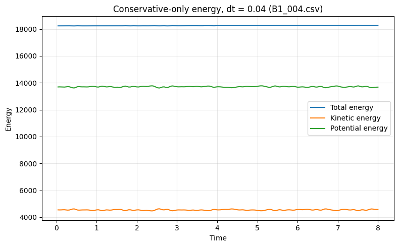

|  | dt | file | comparison end time | relative endpoint drift (%) | maximum relative deviation (%) |
| --- | --- | --- | --- | --- | --- |
| 0 | 0.005 | B1_0005.csv | 8.0 | 0.000027 | 0.000777 |
| 1 | 0.010 | B1_001.csv | 8.0 | -0.003741 | 0.005032 |
| 2 | 0.020 | B1_002.csv | 8.0 | 0.008697 | 0.017402 |
| 3 | 0.040 | B1_004.csv | 8.0 | 0.075694 | 0.111361 |

```
Approximate observed scaling: maximum relative deviation ~ dt^2.33
```

```python
from pathlib import Path
import re

import numpy as np
import pandas as pd
import matplotlib.pyplot as plt

DATA_DIR = Path("data")
PLOT_DT = 0.04  # Optionally set to 0.01, 0.02, 0.04, or 0.005.

# Filename suffix -> timestep. For example, B1_001.csv has dt = 0.01.
DT_BY_SUFFIX = {
    "001": 0.01,
    "002": 0.02,
    "004": 0.04,
    "0005": 0.005,
}

COLUMN_ALIASES = {
    "time": {"time", "t"},
    "step": {"step", "steps", "timestep", "iteration"},
    "kinetic": {"kinetic", "kineticenergy", "ekin", "ek", "k"},
    "potential": {"potential", "potentialenergy", "epot", "ep", "u"},
    "total": {"total", "totalenergy", "etot", "energy", "e"},
}

def normalise(name):
    return re.sub(r"[^a-z0-9]", "", str(name).lower())

def load_energy_file(path, dt):
    # Read CSV data with a header row.
    df = pd.read_csv(path, comment="#")
    df.columns = [str(column).strip() for column in df.columns]

    columns = {normalise(column): column for column in df.columns}

    def find_column(kind):
        return next(
            (columns[name] for name in COLUMN_ALIASES[kind] if name in columns),
            None,
        )

    time_col = find_column("time")
    step_col = find_column("step")
    kinetic_col = find_column("kinetic")
    potential_col = find_column("potential")
    total_col = find_column("total")

    if kinetic_col is None or potential_col is None:
        raise ValueError(
            f"{path.name}: couldn't identify kinetic and potential energy "
            f"columns. Found columns: {list(df.columns)}"
        )

    if step_col is not None:
        steps = pd.to_numeric(df[step_col], errors="coerce")
        time = steps * dt
    elif time_col is not None:
        time = pd.to_numeric(df[time_col], errors="coerce")
    else:
        raise ValueError(f"{path.name}: needs a time or step column.")

    kinetic = pd.to_numeric(df[kinetic_col], errors="coerce")
    potential = pd.to_numeric(df[potential_col], errors="coerce")

    if total_col is not None:
        total = pd.to_numeric(df[total_col], errors="coerce")
    else:
        total = kinetic + potential

    result = pd.DataFrame({
        "time": time,
        "kinetic": kinetic,
        "potential": potential,
        "total": total,
    }).dropna().sort_values("time")

    if result.empty:
        raise ValueError(f"{path.name}: no valid energy rows found.")

    return result

# Match B1_<suffix>.csv filenames and load only the specified B1 runs.
runs = {}
filename_pattern = re.compile(r"^B1_(\d+)\.csv$", re.IGNORECASE)

for path in sorted(DATA_DIR.glob("B1_*")):
    match = filename_pattern.match(path.name)
    if not match:
        continue

    suffix = match.group(1)
    if suffix not in DT_BY_SUFFIX:
        print(f"Skipping {path.name}: suffix {suffix!r} has no timestep mapping.")
        continue

    dt = DT_BY_SUFFIX[suffix]
    runs[dt] = (path, load_energy_file(path, dt))

if not runs:
    expected = ", ".join(f"B1_{suffix}.csv" for suffix in DT_BY_SUFFIX)
    raise FileNotFoundError(
        f"No matching B1 CSV files found in {DATA_DIR.resolve()}. "
        f"Expected: {expected}"
    )

# Restrict comparisons to the same physical time across all runs.
common_end_time = min(data["time"].max() for _, data in runs.values())
print(f"Comparing runs through t = {common_end_time:g}")

# Plot total, kinetic, and potential energy for the selected run.
plot_dt = PLOT_DT if PLOT_DT in runs else min(runs)
plot_path, plot_data = runs[plot_dt]
plot_data = plot_data[plot_data["time"] <= common_end_time]

fig, ax = plt.subplots(figsize=(8, 5))
ax.plot(plot_data["time"], plot_data["total"], label="Total energy")
ax.plot(plot_data["time"], plot_data["kinetic"], label="Kinetic energy")
ax.plot(plot_data["time"], plot_data["potential"], label="Potential energy")
ax.set(
    xlabel="Time",
    ylabel="Energy",
    title=f"Conservative-only energy, dt = {plot_dt:g} ({plot_path.name})",
)
ax.legend()
ax.grid(alpha=0.3)
plt.tight_layout()
plt.show()

# Calculate endpoint drift and maximum deviation over the shared time interval.
rows = []

for dt, (path, data) in sorted(runs.items()):
    data = data[data["time"] <= common_end_time]
    time = data["time"].to_numpy()
    energy = data["total"].to_numpy()

    if len(time) < 2:
        print(f"Skipping drift calculation for {path.name}: too few samples.")
        continue

    initial_energy = energy[0]
    end_energy = np.interp(common_end_time, time, energy)
    energy_with_endpoint = np.append(energy, end_energy)

    if initial_energy == 0:
        endpoint_drift = np.nan
        max_deviation = np.nan
    else:
        endpoint_drift = 100 * (end_energy - initial_energy) / abs(initial_energy)
        max_deviation = (
            100 * np.max(np.abs(energy_with_endpoint - initial_energy))
            / abs(initial_energy)
        )

    rows.append({
        "dt": dt,
        "file": path.name,
        "comparison end time": common_end_time,
        "relative endpoint drift (%)": endpoint_drift,
        "maximum relative deviation (%)": max_deviation,
    })

drift_table = pd.DataFrame(rows).sort_values("dt")
display(drift_table)

# Estimate the power-law scaling from the maximum deviation (the endpoint value of an oscillating error
# is not a drift, so it is not used for the scaling)
valid = drift_table[drift_table["maximum relative deviation (%)"] > 0]
if len(valid) >= 2:
    slope = np.polyfit(np.log(valid["dt"]), np.log(valid["maximum relative deviation (%)"]), 1)[0]
    print(f"Approximate observed scaling: maximum relative deviation ~ dt^{slope:.2f}")
else:
    print("Not enough nonzero deviations to estimate timestep scaling.")
```

### B2) Ideal-gas structure

Disable the conservative interactions, keeping the dissipative and random forces on. The beads then interact only through friction and noise, so their equilibrium structure must be that of an ideal gas.

Deliver a **figure** of $g(r)$ for this run, showing it is flat and equal to 1 within the noise, and a sentence on what a *non*-flat result would have told you (this test catches both a broken $g(r)$ normalisation and a conservative force that is not really off).

### B3) Velocity statistics

Verify that the velocity distribution matches the imposed temperature (Maxwellian, with the correct variance), independent of the conservative interactions.

Deliver:

- a **figure** of the velocity histogram with the Maxwell-Boltzmann prediction on top, for a run with the conservative force on and one with it off;
- a **table** of the measured $kBT$ from the variance in both cases, next to the imposed value, and a sentence comparing the deviation you find with what Groot and Warren report for the Verlet scheme with $λ=1/2$ at $Δt=0.04$ (Fig. 1 and the text beside it);
- a short statement of what this verifies about your $σ$ and $γ$: if you had used a wrong fluctuation-dissipation relation, what would this table look like?

*Results B2*

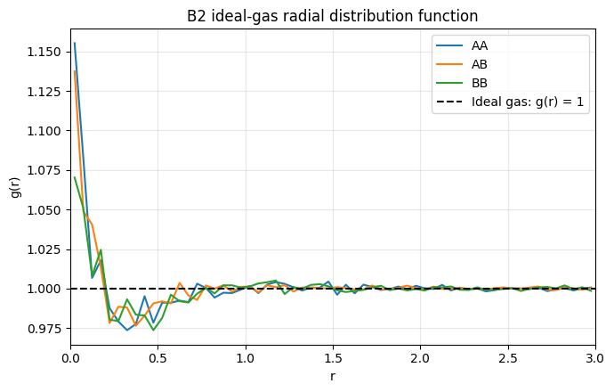

```python
#B2/B3:
from pathlib import Path

import pandas as pd
import matplotlib.pyplot as plt

path = Path("data/B2_rdf_ideal_gas.csv")
df = pd.read_csv(path)

required = {"pair", "r_min", "r_max", "g_r"}
if not required.issubset(df.columns):
    raise ValueError(f"Expected columns {required}; found {list(df.columns)}")

for col in ("r_min", "r_max", "g_r"):
    df[col] = pd.to_numeric(df[col], errors="coerce")
df = df.dropna(subset=["pair", "r_min", "r_max", "g_r"])
df["r"] = (df["r_min"] + df["r_max"]) / 2

# This file's g_r values are all zero, so it cannot produce a valid B2 plot.
if df["g_r"].abs().max() == 0:
    raise ValueError(
        "Every g_r value in B2_rdf_ideal_gas.csv is zero. "
        "The issue is in the C RDF calculation/output, not the Python plotting code."
    )

fig, ax = plt.subplots(figsize=(7, 4.5))
for pair, group in df.groupby("pair"):
    group = group.sort_values("r")
    ax.plot(group["r"], group["g_r"], label=pair)

ax.axhline(1, color="black", linestyle="--", label="Ideal gas: g(r) = 1")
ax.set(
    xlabel="r",
    ylabel="g(r)",
    title="B2 ideal-gas radial distribution function",
    xlim=(0, 3),
)
ax.legend()
ax.grid(alpha=0.3)
plt.tight_layout()
plt.show()
```

*Conclusion B2*

- **Result.** $g(r)$ is 1 for AA, AB and BB: the bin values have mean 1.00 and standard deviation 0.01 to 0.02. Only the first bins ($r<0.15$) are higher, because there are very few pairs there (0.6 expected per sample in the first bin) and the noise is large.
- **Why this is the configuration of an ideal gas.** With the conservative force off, the remaining forces are not derived from a potential, so $U=0$. They only change velocities, and by the fluctuation-dissipation relation they leave the equilibrium distribution unchanged. The equilibrium positions then have Boltzmann weight $e−U/kBT=1$: all positions are equally likely and independent of each other. That is the ideal gas, with $g(r)=1$.
- **What a non-flat result would have told us.** Either the $g(r)$ normalisation is wrong (this happened several times in our first tests), or the conservative force is not really off (a peak near $r=0.9$ and a depletion at small $r$, as in C1).

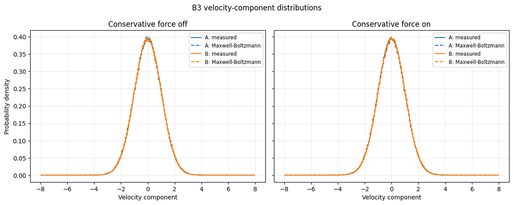

|  | run | type | component | samples | kBT_measured | kBT_target | relative_error_percent |
| --- | --- | --- | --- | --- | --- | --- | --- |
| 0 | off | A | x | 241500 | 1.030073 | 1.0 | 3.007315 |
| 1 | off | A | y | 241500 | 1.028603 | 1.0 | 2.860269 |
| 2 | off | A | z | 241500 | 1.030125 | 1.0 | 3.012494 |
| 3 | off | B | x | 241500 | 1.035601 | 1.0 | 3.560053 |
| 4 | off | B | y | 241500 | 1.030738 | 1.0 | 3.073802 |
| 5 | off | B | z | 241500 | 1.032048 | 1.0 | 3.204790 |
| 6 | off | all | sample-weighted mean | 1449000 | 1.031198 | 1.0 | 3.119787 |
| 7 | on | A | x | 241500 | 1.027603 | 1.0 | 2.760335 |
| 8 | on | A | y | 241500 | 1.028049 | 1.0 | 2.804947 |
| 9 | on | A | z | 241500 | 1.029984 | 1.0 | 2.998390 |
| 10 | on | B | x | 241500 | 1.031688 | 1.0 | 3.168828 |
| 11 | on | B | y | 241500 | 1.030801 | 1.0 | 3.080093 |
| 12 | on | B | z | 241500 | 1.033376 | 1.0 | 3.337581 |
| 13 | on | all | sample-weighted mean | 1449000 | 1.030250 | 1.0 | 3.025029 |

```python
# B3:

from pathlib import Path

import matplotlib.pyplot as plt
import pandas as pd

DATA_DIR = Path("data")
RUNS = ("off", "on")

# Load the C-generated histograms and temperature statistics.
histograms = {}
statistics = {}

for run in RUNS:
    prefix = DATA_DIR / f"B3_velocity_{run}"
    hist_path = Path(f"{prefix}_velocity_hist.csv")
    stats_path = Path(f"{prefix}_velocity_stats.csv")

    if not hist_path.exists() or not stats_path.exists():
        raise FileNotFoundError(
            f"Missing B3 output for conservative force {run}. "
            f"Expected {hist_path} and {stats_path}."
        )

    histograms[run] = pd.read_csv(hist_path)
    statistics[run] = pd.read_csv(stats_path)

# Plot each run's measured velocity-component distribution against the
# Maxwell-Boltzmann prediction written by the simulation.
fig, axes = plt.subplots(1, 2, figsize=(12, 4.8), sharey=True)

for ax, run in zip(axes, RUNS):
    data = histograms[run]

    for particle_type, group in data.groupby("type"):
        group = group.sort_values("velocity")
        line, = ax.plot(
            group["velocity"],
            group["density"],
            drawstyle="steps-mid",
            label=f"{particle_type}: measured",
        )
        ax.plot(
            group["velocity"],
            group["maxwell_boltzmann"],
            linestyle="--",
            color=line.get_color(),
            label=f"{particle_type}: Maxwell-Boltzmann",
        )

    ax.set_title(f"Conservative force {run}")
    ax.set_xlabel("Velocity component")
    ax.grid(alpha=0.25)
    ax.legend(fontsize="small")

axes[0].set_ylabel("Probability density")
fig.suptitle("B3 velocity-component distributions")
fig.tight_layout()

fig.savefig("data/B3_velocity_comparison.png", dpi=150)
plt.show()

# Create a per-component table and a sample-weighted summary for each run.
rows = []

for run in RUNS:
    stats = statistics[run]

    for _, row in stats.iterrows():
        rows.append(
            {
                "run": run,
                "type": row["type"],
                "component": row["component"],
                "samples": int(row["samples"]),
                "kBT_measured": float(row["kBT_measured"]),
                "kBT_target": float(row["kBT_target"]),
            }
        )

    total_samples = stats["samples"].sum()
    if total_samples == 0:
        raise ValueError(f"No velocity samples found for conservative force {run}.")

    measured_mean = (
        stats["kBT_measured"] * stats["samples"]
    ).sum() / total_samples
    target_values = stats["kBT_target"].unique()
    if len(target_values) != 1:
        raise ValueError(f"Inconsistent target kBT values for conservative force {run}.")

    rows.append(
        {
            "run": run,
            "type": "all",
            "component": "sample-weighted mean",
            "samples": int(total_samples),
            "kBT_measured": measured_mean,
            "kBT_target": float(target_values[0]),
        }
    )

temperature_table = pd.DataFrame(rows)
temperature_table["relative_error_percent"] = (
    100
    * (temperature_table["kBT_measured"] - temperature_table["kBT_target"])
    / temperature_table["kBT_target"]
)



display(temperature_table)
```

*B3 conclusion:*

- **What was measured.** Velocity components of all beads, sampled every 100 steps after the first 4000 (241 500 samples per type and component), for a run with the conservative force on and one with it off ($a=25$, box $103$, $Δt=0.04$). The histograms follow the Maxwell-Boltzmann Gaussian of variance $kBT/m$ closely (figure) and the mean velocities are zero within 0.005.
- **Table.** The measured $kBT$ is 1.03 for every type and component (spread $±0.005$): 3.0% above the imposed value with the conservative force on and 3.1% with it off. The temperature does not depend on the conservative force, as it must: it is fixed by the dissipative and random forces.
- **Comparison with Groot and Warren.** For the Verlet scheme with $λ=12$ at $Δt=0.04$ they find a temperature 2% too high (3% at $Δt=0.05$; Fig. 1 and the text beside it, at $ρ=4$ and $σ=3$). We find 3%: the same order and sign. This is a time-step error of the integrator, not an error in the forces. We did not check that it shrinks with $Δt$.
- **What this verifies about $σ$ and $γ$.** The random force heats and the friction cools, and they balance at $kBT=σ2/2γ$. With $σ2=2γkBT$ this is the imposed temperature. If $σ2$ were wrong by a factor $f$, the table would show a temperature off by that factor (for example 2 instead of 1 for $f=2$), not 3%. The shape of the histogram would still be Gaussian, so the variance is what tests the relation.

## Part C: Validation for monomers (N = 1)

*In the oral you should be able to:* say what agreement with a published simulation result does and does not validate; explain how χ is measured from composition profiles and what must be true of the profiles first; explain the sign, magnitude and factor of two of your surface tension.

**Every demixing run** (C2, C3, C4, and Part D) uses the same geometry. The box is $20×10×10$, elongated along $x$, with 6000 beads, and starts with A in the half $x<10$ and B in the half $x>10$. The two phases then form two flat slabs with **two flat interfaces perpendicular to $x$**, and the two bulk regions are wide enough to read a composition from. In a cubic box the system can separate along any axis, or not into flat slabs at all, and then neither the composition profile nor the surface tension means anything. Groot and Warren elongate their box along $z$; we use $x$ throughout, so read their $z$ as our $x$.

The **composition profile** is the number density of A and of B in thin slabs perpendicular to $x$ (a bin width of about 0.2 to 0.5), averaged over the run after equilibration, and the A fraction $ϕA(x)=ρA/(ρA+ρB)$ computed from them. Write it out in blocks during the run (every few thousand steps), not only once at the end: C2 asks when the profile became steady, and the error estimates of C3 come from the scatter between blocks.

### C1) Radial distribution function

Reproduce the $g(r)$ of Fig. 2 ($ρ=3$, $a=25$).

Deliver a **figure** with your $g(r)$ and the published curve on the same axes (digitise a few points from the figure if you have no data file), and a sentence on where they agree and where they do not. State your run length and how you know $g(r)$ has converged.

*Results (C1):*

- **Run.** 3000 beads, $a=25$, $ρ=3$, 20 000 steps; $g(r)$ sampled every 20 steps after step 4000 (bin width 0.05).
- **Agreement with Fig. 2.** $g=0$ at small $r$ (the soft core can overlap, but only at a cost), one maximum of 1.15 at $r≈0.9$, and $g→1$ beyond $rc$. The curve also dips to about 0.95 near $r≈1.2$ (outside the range of the paper's figure).
- **Difference.** Between $r=0.5$ and 0.75 our curve lies about 0.1 above the points we read off the figure. We read these points by eye (accuracy 0.05 to 0.1), so the difference is not significant. A real difference would mean that the repulsion acts over a different range; the published data would be needed to decide.
- **Converged.** The four blocks of 4000 steps agree within 0.005 at the peak (zoom panel).
- **What this validates.** The conservative force, the cut-off and the $g(r)$ normalisation in a fluid with all forces on. It says nothing about unlike pairs.

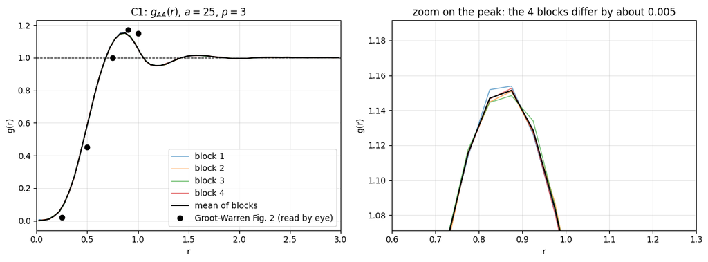

```
blocks: 4 | peak g = 1.151 at r = 0.875 | max block scatter at the peak: 0.002
```

```python
# C1: g(r) overlaid with Fig. 2
import numpy as np, pandas as pd, matplotlib.pyplot as plt

# Points read off Fig. 2 of Groot & Warren by eye (r, g(r)); estimated accuracy about +-0.05 in g.
# The paper gives no data file, so these are approximate and only meant to compare shape and peak.
FIG2_POINTS = [(0.25, 0.02), (0.50, 0.45), (0.75, 1.00), (0.90, 1.17), (1.00, 1.15)]

blocks = pd.read_csv("data/C1_a25_rdf_blocks.csv")
blocks = blocks[blocks.pair == "AA"]
blocks["r"] = (blocks.r_min + blocks.r_max) / 2
piv = blocks.pivot(index="r", columns="block", values="g_r")
piv = piv.iloc[:, 1:]   # first block holds a single sample (step 4000): drop it
mean, spread = piv.mean(axis=1), piv.std(axis=1)

fig, (ax, zoom) = plt.subplots(1, 2, figsize=(12, 4.5))
for a in (ax, zoom):
    for k in piv.columns:
        a.plot(piv.index, piv[k], lw=1, alpha=0.7, label=f"block {k}")
    a.plot(piv.index, mean, "k", lw=1.5, label="mean of blocks")
    a.axhline(1, color="k", ls="--", lw=0.8)
    a.set_xlabel("r"); a.set_ylabel("g(r)"); a.grid(alpha=0.3)
if FIG2_POINTS:
    ax.plot(*zip(*FIG2_POINTS), "ko", label="Groot-Warren Fig. 2 (read by eye)")
ax.set(xlim=(0, 3), title=r"C1: $g_{AA}(r)$, $a=25$, $\rho=3$")
ax.legend()
zoom.set(xlim=(0.6, 1.3), ylim=(mean.max() - 0.08, mean.max() + 0.04),
         title="zoom on the peak: the 4 blocks differ by about 0.005")
plt.tight_layout(); plt.show()

print("blocks:", piv.shape[1], "| peak g =", round(mean.max(), 3), "at r =", round(mean.idxmax(), 3),
      "| max block scatter at the peak:", round(spread[mean.idxmax()], 3))
```

### C2) Binary demixing

Reproduce the phase separation of Fig. 6, using the parameters in its caption ($aAB=37$) and the geometry above.

Deliver:

- a **snapshot** of the demixed system (OVITO, beads coloured by type);
- a **figure** of the composition profile along $x$, showing the two bulk plateaus and the two interfaces;
- a statement of how long the run needed to reach a steady profile, and how you decided it had.

*Results (C2):*

- **Run.** $20×10×10$ box, 6000 beads, $aAB=37$, A started in $x<10$ and B in $x>10$, 60 000 steps.
- **Snapshot (OVITO).** Two flat slabs, A (red) and B (blue), separated by two flat interfaces perpendicular to $x$ (the second one lies across the periodic boundary, at $x=0≡20$).
- **Profile.** Two plateaus of almost pure A and pure B, and two interfaces about $2rc$ wide. The total density is about 3 in the bulk with a small dip at the interfaces, as in Fig. 6.
- **When it was steady, and how we decided.** The bulk $ϕA$ of the B-rich phase is the slowest quantity to settle: the initial interface is sharp, and A beads still have to diffuse into the B phase. We therefore follow it block by block (bottom panel). The blocks ending at steps 5000, 10 000 and 15 000 are 0.03, 0.04 and 0.055, still changing. After step 20 000 the blocks scatter by 0.003 around 0.041 without a trend (a straight-line fit gives $−0.0007±0.0010$ per 10 000 steps, zero within error). So the profile is steady from about step 20 000 ($t=800$), and the first 20 000 steps are discarded in all averages.

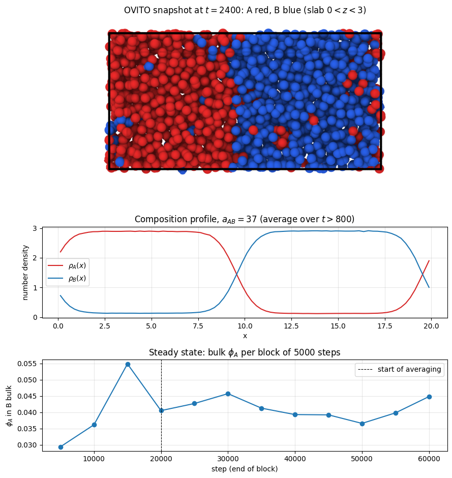

```
blocks before step 20000: bulk phi_A = 0.029, 0.036, 0.055, 0.041
blocks after  step 20000: mean 0.0412, scatter 0.0031, trend -0.0007 +- 0.0010 per 10 000 steps
```

```python
# C2: OVITO snapshot, composition profile, steady state
import numpy as np, pandas as pd, matplotlib.pyplot as plt, matplotlib.image as mpimg

USE_FROM = 20000                                   # first 20 000 steps are discarded
prof = pd.read_csv("data/C2_a37_profile.csv")
prof["phi"] = prof.rho_A / (prof.rho_A + prof.rho_B)
avg = prof[prof.step_end > USE_FROM].groupby("x")[["rho_A", "rho_B"]].mean()
bulkB = prof[(prof.x > 12.5) & (prof.x < 17.5)].groupby("step_end").phi.mean()   # bulk phi_A of the B-rich phase

fig = plt.figure(figsize=(9, 9.5))
grid = fig.add_gridspec(3, 1, height_ratios=[2.2, 1.2, 1.2])
ax0 = fig.add_subplot(grid[0])
ax0.imshow(mpimg.imread("data/C2_ovito_snapshot.png")); ax0.axis("off")
ax0.set_title("OVITO snapshot at $t=2400$: A red, B blue (slab $0<z<3$)")
ax1 = fig.add_subplot(grid[1])
ax1.plot(avg.index, avg.rho_A, c="tab:red", label="$\\rho_A(x)$")
ax1.plot(avg.index, avg.rho_B, c="tab:blue", label="$\\rho_B(x)$")
ax1.set(xlabel="x", ylabel="number density", title="Composition profile, $a_{AB}=37$ (average over $t>800$)")
ax1.legend(); ax1.grid(alpha=0.3)
ax2 = fig.add_subplot(grid[2])
ax2.plot(bulkB.index, bulkB.values, "o-")
ax2.axvline(USE_FROM, color="k", ls="--", lw=0.8, label="start of averaging")
ax2.set(xlabel="step (end of block)", ylabel="$\\phi_A$ in B bulk", title="Steady state: bulk $\\phi_A$ per block of 5000 steps")
ax2.grid(alpha=0.3); ax2.legend()
plt.tight_layout(); plt.savefig("data/C2_snapshot_profile.png", dpi=150); plt.show()

# is the profile steady? straight-line fit through the blocks after the start of the averaging
steady = bulkB[bulkB.index > USE_FROM]
(k, _), cov = np.polyfit(steady.index, steady.values, 1, cov=True)
print(f"blocks before step {USE_FROM}: bulk phi_A = " + ", ".join(f"{v:.3f}" for v in bulkB[bulkB.index <= USE_FROM]))
print(f"blocks after  step {USE_FROM}: mean {steady.mean():.4f}, scatter {steady.std():.4f}, "
      f"trend {k * 1e4:+.4f} +- {np.sqrt(cov[0, 0]) * 1e4:.4f} per 10 000 steps")
```

### C3) Measuring the χ-parameter

Measure χ with Eq. (18) from the composition profiles of demixed runs at $ρ=3$, for this edition's series

$$aAB∈{35, 39, 43, 47},aAA=aBB=25.$$

For monomers $NA=1$, and $ϕA$ in Eq. (18) is the A fraction in the bulk of the B-rich phase. Read it from the plateau of the profile, away from both interfaces.

Deliver:

- a **figure** with the four composition profiles;
- a **table** of the bulk compositions and the resulting χ per $aAB$, each with an error estimate;
- a **figure** of χ against $Δa=aAB−aAA$ with a linear fit, the fitted slope stated, and the slope of Eq. (24) (Fig. 7) for comparison. Groot and Warren fit only the points with $χ>3$ (p. 4429), with the same integrator and $Δt$ as yours: compare like with like, and report the fit over all four points as well.

Then state what must be true of the profiles before Eq. (18) may be applied at all, and confirm that it is true of yours.

*Results (C3):*

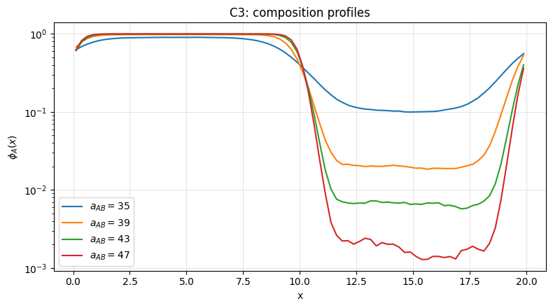

|  | a_AB | delta_a | phi_A | err_phi | chi | err_chi | plateau_slope | trend_in_errors | mirror_check |
| --- | --- | --- | --- | --- | --- | --- | --- | --- | --- |
| 0 | 35 | 10 | 0.1060 | 0.0020 | 2.7062 | 0.0132 | 0.0015 | -0.2085 | 0.0024 |
| 1 | 39 | 14 | 0.0196 | 0.0010 | 4.0719 | 0.0441 | -0.0003 | -0.7959 | -0.0010 |
| 2 | 43 | 18 | 0.0066 | 0.0004 | 5.0754 | 0.0550 | -0.0002 | 0.0718 | 0.0014 |
| 3 | 47 | 22 | 0.0017 | 0.0003 | 6.3901 | 0.1524 | -0.0002 | -2.0540 | -0.0002 |

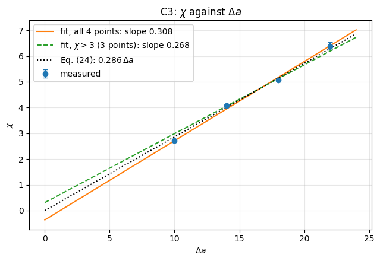

```
slope, all four points  : 0.308  (through origin 0.286)
slope, chi > 3 (3 pts) : 0.268  (through origin 0.288)
Eq. (24)                : 0.286
```

```python
# C3: composition profiles; chi against Delta a with linear fit
import numpy as np, pandas as pd, matplotlib.pyplot as plt

RUNS = {35: "C3_a35", 39: "C3_a39", 43: "C3_a43", 47: "C3_a47"}
EQ24_SLOPE = 0.286            # Groot & Warren, Eq. (24), rho = 3
USE_FROM = 20000

def chi_of_phi(phi):          # Eq. (18) with N_A = N_B = 1
    return np.log((1 - phi) / phi) / (1 - 2 * phi)

rows, profiles = [], {}
fig, ax = plt.subplots(figsize=(8, 4.5))
for aab, run in RUNS.items():
    p = pd.read_csv(f"data/{run}_profile.csv")
    p["phi"] = p.rho_A / (p.rho_A + p.rho_B)
    q = p[p.step_end > USE_FROM]
    avg = q.groupby("x").phi.mean()
    ax.plot(avg.index, avg.values, label=f"$a_{{AB}}={aab}$")
    win = q[(q.x > 12.5) & (q.x < 17.5)]
    per_block = win.groupby("block").phi.mean()                  # bulk of the B-rich phase
    phi, dphi = per_block.mean(), per_block.std(ddof=1) / np.sqrt(len(per_block))
    chi = chi_of_phi(phi)
    dchi = abs(chi_of_phi(phi + dphi) - chi_of_phi(phi - dphi)) / 2
    # flatness of the plateau: slope of phi(x) in the window
    slope = np.polyfit(win.groupby("x").phi.mean().index, win.groupby("x").phi.mean().values, 1)[0]
    # steady state: trend of the bulk phi_A over the blocks used, in units of its error
    (kt, _), cov = np.polyfit(per_block.index, per_block.values, 1, cov=True)
    # symmetric coexistence: the A-rich bulk must contain a B fraction equal to phi_A of the B-rich bulk
    arich = q[(q.x > 2.5) & (q.x < 7.5)].groupby("block").phi.mean().mean()
    rows.append(dict(a_AB=aab, delta_a=aab - 25, phi_A=phi, err_phi=dphi, chi=chi, err_chi=dchi,
                     plateau_slope=slope, trend_in_errors=kt / np.sqrt(cov[0, 0]), mirror_check=arich + phi - 1))
ax.set(xlabel="x", ylabel="$\\phi_A(x)$", yscale="log", title="C3: composition profiles")
ax.legend(); ax.grid(alpha=0.3); plt.tight_layout(); plt.show()

tab = pd.DataFrame(rows)
display(tab.round(4))

da, chi, err = tab.delta_a.values, tab.chi.values, tab.err_chi.values
def fit(mask):
    w = 1 / np.maximum(err[mask], 1e-9)
    k, b = np.polyfit(da[mask], chi[mask], 1, w=w)
    k0 = np.sum(da[mask] * chi[mask]) / np.sum(da[mask] ** 2)       # through the origin
    return k, b, k0
sel = chi > 3
k_all, b_all, k0_all = fit(np.ones_like(sel))
k_hi, b_hi, k0_hi = fit(sel)

fig, ax = plt.subplots(figsize=(6.5, 4.5))
ax.errorbar(da, chi, err, fmt="o", capsize=3, label="measured")
xs = np.linspace(0, 24, 50)
ax.plot(xs, k_all * xs + b_all, label=f"fit, all 4 points: slope {k_all:.3f}")
ax.plot(xs, k_hi * xs + b_hi, "--", label=f"fit, $\\chi>3$ ({sel.sum()} points): slope {k_hi:.3f}")
ax.plot(xs, EQ24_SLOPE * xs, "k:", label="Eq. (24): $0.286\\,\\Delta a$")
ax.set(xlabel="$\\Delta a$", ylabel="$\\chi$", title="C3: $\\chi$ against $\\Delta a$")
ax.legend(); ax.grid(alpha=0.3); plt.tight_layout(); plt.show()
print(f"slope, all four points  : {k_all:.3f}  (through origin {k0_all:.3f})")
print(f"slope, chi > 3 ({sel.sum()} pts) : {k_hi:.3f}  (through origin {k0_hi:.3f})")
print(f"Eq. (24)                : {EQ24_SLOPE}")
```

### C4) Surface tension *(new this edition)*

For the same demixed runs as C3, obtain the interfacial tension from Eq. (31). With the interface normal along $x$ it reads

$$σs=∫[pxx(x)−12(pyy(x)+pzz(x))]dx,$$

the normal minus the tangential pressure, integrated across the interface. You do **not** need the pressure as a function of $x$. What you need is this:

1. **The diagonal of the pressure tensor of the whole box**, at every sampling step: $Pαα=1V[∑imviα2+∑i<jrij,αFij,α]$, $α=x,y,z$, with $𝐅ij$ the conservative and spring forces, as in Eq. (15). Your A2 code accumulates only the scalar virial $∑𝐫ij·𝐅ij$; accumulate its three components separately, in the same place.
2. **The step from Eq. (31) to those three numbers.** Take the integral over the whole periodic box. Derive $σs$ in terms of $Lx$ and the box averages $Pxx$, $Pyy$, $Pzz$, say where the **two** interfaces in the box enter, and explain why the bulk regions add nothing to the integral.
3. **A time average with an honest error.** Successive samples are strongly correlated, so the naive standard error of the mean is too small; use block averages.
4. **A control run** at $aAB=25$, with the same separated start: one phase, no interface, so $σs$ must vanish within its error. That checks your tensor for a bias between $x$ and the other two directions; a wrong overall factor would pass it, so check the magnitude too, against Groot and Warren's monomer surface tension, Eq. (36).

Deliver:

- a **table** and a **figure** of $σs$ against $Δa$, with error bars, including the control;
- your derivation of item 2;
- a discussion of three things: the **sign** of $σs$ and why it must be that sign for a stable interface; the **trend** with $Δa$; and the **limit** as $Δa$ approaches the mixing point, where the two phases become identical.

*Results (C4):*

**Derivation.** Integrate Eq. (31) over the whole periodic box, $0<x<Lx$. Because $∫pαα(x)dx=LxPαα$ (the box-averaged pressure that we sample), the integral is $Lx[Pxx−12(Pyy+Pzz)]$. The box contains **two** interfaces (at $x≈Lx/2$ and at $x≈0≡Lx$) and Eq. (31) is for one, so

$$σs=Lx2[Pxx−12(Pyy+Pzz)].$$

In the bulk the fluid is isotropic ($pxx=pyy=pzz$), so the bulk adds nothing and only the interfaces contribute.

**Method.** $Pαα=1V[∑mvα2+∑rαFα]$ with the conservative force (Eq. 15), sampled every 10 steps, first 20% discarded. The error is the standard error of 8 block means. Successive samples are 0.4 time units apart and practically uncorrelated here (lag-1 autocorrelation $≤0.03$, column `lag1_autocorr`), so the naive error (0.015) and the block error (0.011 to 0.025) agree within the scatter expected from only 8 blocks. We quote the block error.

**Results** (table and figure above):

- **Control** ($aAB=25$): $σs=0.009±0.017$, zero within error, with $P=23.7$ as the equation of state predicts. There is no bias between $x$ and $y,z$.
- **Magnitude.** Measured/Eq. (36) is 0.99 to 1.02 for $Δa≥14$ and 1.05 to 1.08 for $Δa=10,12$, so the overall factor (including the factor 2) is right and not only the zero of the control.
- **Sign.** $σs>0$: the interface costs free energy. With a negative value the interface would grow until the phases mix, so two stable slabs would not exist. In terms of pressure, the tangential pressure at the interface is lower than the normal one.
- **Trend.** $σs$ grows with $Δa$ (0.23 to 1.79 for $Δa=10$ to 22): the more unlike beads repel, the more the interface costs.
- **Limit.** $σs→0$ at the mixing point, where the two phases become identical and there is no interface. Eq. (36) goes to zero at $χ=2.36$ as $(1−2.36/χ)3/2$.

|  | delta_a | a_AB | sigma_s | err_blocks | err_naive | lag1_autocorr | P_iso |
| --- | --- | --- | --- | --- | --- | --- | --- |
| 0 | 0 | 25 | 0.0088 | 0.0174 | 0.0147 | -0.0056 | 23.7329 |
| 1 | 10 | 35 | 0.2336 | 0.0248 | 0.0151 | 0.0023 | 25.2379 |
| 2 | 12 | 37 | 0.5705 | 0.0179 | 0.0152 | 0.0259 | 24.8074 |
| 3 | 14 | 39 | 0.8648 | 0.0138 | 0.0150 | 0.0077 | 24.5726 |
| 4 | 18 | 43 | 1.3655 | 0.0165 | 0.0151 | 0.0308 | 24.3696 |
| 5 | 22 | 47 | 1.7862 | 0.0109 | 0.0149 | 0.0175 | 24.3052 |

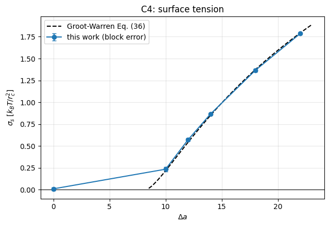

```
control: sigma_s = 0.0088 +- 0.0174  (zero within 0.5 sigma)
```

|  | delta_a | sigma_s | err_blocks | sigma_eq36 | measured/Eq.36 |
| --- | --- | --- | --- | --- | --- |
| 0 | 0 | 0.009 | 0.017 | 0.000 | NaN |
| 1 | 10 | 0.234 | 0.025 | 0.216 | 1.081 |
| 2 | 12 | 0.570 | 0.018 | 0.541 | 1.054 |
| 3 | 14 | 0.865 | 0.014 | 0.849 | 1.019 |
| 4 | 18 | 1.365 | 0.017 | 1.373 | 0.994 |
| 5 | 22 | 1.786 | 0.011 | 1.793 | 0.996 |

```python
# C4: sigma_s against Delta a, with the control
import numpy as np, pandas as pd, matplotlib.pyplot as plt

RUNS = {0: "C4_a25", 10: "C3_a35", 12: "C2_a37", 14: "C3_a39", 18: "C3_a43", 22: "C3_a47"}
LX, NBLOCK, SKIP = 20.0, 8, 0.2
def EQ36(delta_a, rho=3.0):
    """Groot-Warren Eq. (36): sigma = 0.75 rho kT r_c chi^0.26 [1 - 2.36/chi]^1.5, with chi = 0.286 Delta a (rho = 3)."""
    chi = 0.286 * delta_a
    return 0.75 * rho * chi ** 0.26 * (1 - 2.36 / chi) ** 1.5

rows = []
for da, run in RUNS.items():
    p = pd.read_csv(f"data/{run}_pressure.csv")
    p = p.iloc[int(SKIP * len(p)):]
    s = 0.5 * LX * (p.Pxx - 0.5 * (p.Pyy + p.Pzz))               # instantaneous sigma_s
    blocks = np.array_split(s.values, NBLOCK)
    bm = np.array([b.mean() for b in blocks])
    naive = s.std(ddof=1) / np.sqrt(len(s))
    lag1 = np.corrcoef(s.values[:-1], s.values[1:])[0, 1]          # correlation of successive samples (0.4 time units apart)
    rows.append(dict(delta_a=da, a_AB=25 + da, sigma_s=bm.mean(), err_blocks=bm.std(ddof=1) / np.sqrt(NBLOCK),
                     err_naive=naive, lag1_autocorr=lag1, P_iso=(p.Pxx + p.Pyy + p.Pzz).mean() / 3))
tab = pd.DataFrame(rows)
display(tab.round(4))

fig, ax = plt.subplots(figsize=(6.5, 4.5))
ax.errorbar(tab.delta_a, tab.sigma_s, tab.err_blocks, fmt="o-", capsize=3, label="this work (block error)")
ds = np.linspace(8.5, 23, 60)
ax.plot(ds, [EQ36(d) for d in ds], "k--", label="Groot-Warren Eq. (36)")
ax.axhline(0, color="k", lw=0.8)
ax.set(xlabel="$\\Delta a$", ylabel="$\\sigma_s\\ [k_BT/r_c^2]$", title="C4: surface tension")
ax.grid(alpha=0.3); ax.legend(); plt.tight_layout(); plt.show()

ctrl = tab[tab.delta_a == 0].iloc[0]
print(f"control: sigma_s = {ctrl.sigma_s:.4f} +- {ctrl.err_blocks:.4f}  (zero within {abs(ctrl.sigma_s)/ctrl.err_blocks:.1f} sigma)")
tab["sigma_eq36"] = [EQ36(d) if d > 0 else 0.0 for d in tab.delta_a]
tab["measured/Eq.36"] = tab.sigma_s / tab.sigma_eq36.where(tab.sigma_eq36 > 0)
display(tab[["delta_a", "sigma_s", "err_blocks", "sigma_eq36", "measured/Eq.36"]].round(3))
```

## Part D: Validation for chains (N > 1)

*In the oral you should be able to:* explain why longer chains demix at smaller Δa, and what Eq. (27)'s χN means for a symmetric blend.

For chains of equal length $NA=NB=N$, Eq. (18) gives the product $χN$, with $ϕA$ the fraction of A **beads** in the B-rich phase. Demixing is governed by $χN$, so the values of $Δa$ that work for monomers are far too large for chains: at $Δa=16$ every chain length used here demixes completely, no A bead is left in the B-rich phase, $ϕA=0$ and Eq. (18) cannot be evaluated. That is why Part D uses much smaller $Δa$, and different values for each $N$ (see the run plan). Close to its critical point every interface is wide, and a chain is several bead diameters long: check, for each run, that the part of the profile you call bulk is really flat.

### D1) Snapshot

Provide a **snapshot** of equilibrated bead-spring chains with $N=5$ ($a=25$ for every pair, cubic box), and a **number** characterising the chains themselves: the mean-square end-to-end distance, compared with that of an ideal chain with the same springs (derive it: $N−1$ independent harmonic bonds with spring constant $C$). This is your check that the springs and the initialisation are doing what you think; say why the two numbers need not agree.

### D2) Two-phase simulations

Perform demixing simulations for chain lengths $N=3$, $5$ and $10$, all at $Δa=3$ ($aAB=28$).

Deliver a **figure** with the composition profiles of the three chain lengths on one set of axes, in the style of Fig. 6, so the effect of $N$ is visible in one figure, and a **snapshot** of each.

### D3) χ-parameter for chains

Measure χ for the chain systems, with a separate series of $Δa$ for each chain length:

| $N$ | $Δa$ |
| --- | --- |
| 3 | 3, 5, 7 |
| 5 | 2, 3.5, 5 |
| 10 | 1, 1.5, 2 |

($N=3$ at $Δa=3$ is the D2 run.)

Deliver a **table** of χ and $χN$ against $N$ and $Δa$, and a **figure** comparing your $χN/Δa$ with Eq. (27) and Fig. 8. Then answer the physical question: at fixed $Δa$, why do longer chains demix more readily? Argue it from your table, from $χN$ rather than from the pictures.

*Results (D1-D3):* D1 and D2 are answered below their cells. **D3:**

```python
# D: chain statistics, composition profiles, chi(N) against Eq. (27)
#D1:

import csv
from pathlib import Path

N = 5
kT = 1.0
C = 2.0

with Path("data/D1_chain_size.csv").open(newline="") as file:
    result = next(csv.DictReader(file))

measured_r2 = float(result["mean_square_end_to_end"])
ideal_r2 = 3 * (N - 1) * kT / C

print(f"Chains: {result['chains']}")
print(f"Samples: {result['samples']}")
print(f"Measured mean-square end-to-end distance: {measured_r2:.4f}")
print(f"Ideal-chain mean-square end-to-end distance: {ideal_r2:.4f}")
```

```
Chains: 600
Samples: 96600
Measured mean-square end-to-end distance: 6.7511
Ideal-chain mean-square end-to-end distance: 6.0000
```

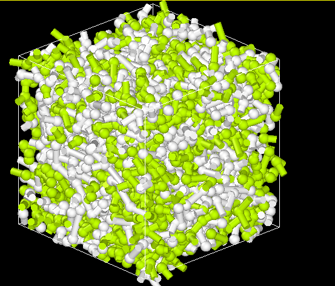

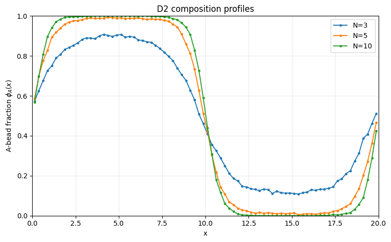

```
Simulation: <R^2> = 6.7511
Ideal chain: <R^2> = 6.0000
```

```python
# Results D2
from pathlib import Path
import csv

import matplotlib.pyplot as plt
import numpy as np


DATA_DIR = Path("data")
CHAIN_LENGTHS = (3, 5, 10)
PDB_FILES = {n: DATA_DIR / f"D2_N{n}.pdb" for n in CHAIN_LENGTHS}

BOX = np.array([20.0, 10.0, 10.0])
BIN_WIDTH = 0.25
EQUILIBRATION_FRACTION = 0.33
EXPECTED_BEADS_PER_FRAME = 6000


def read_composition_profile(pdb_path):
    """Return time-averaged bead densities and A fraction versus x."""
    n_bins = round(BOX[0] / BIN_WIDTH)
    edges = np.linspace(0.0, BOX[0], n_bins + 1)
    frames_a = []
    frames_b = []
    counts_a = np.zeros(n_bins, dtype=np.int64)
    counts_b = np.zeros(n_bins, dtype=np.int64)
    in_model = False
    beads_in_model = 0

    with pdb_path.open(encoding="utf-8") as pdb:
        for line in pdb:
            record = line[:6].strip()

            if record == "MODEL":
                in_model = True
                counts_a.fill(0)
                counts_b.fill(0)
                beads_in_model = 0

            elif record == "ENDMDL" and in_model:
                if beads_in_model != EXPECTED_BEADS_PER_FRAME:
                    raise ValueError(
                        f"{pdb_path}: expected {EXPECTED_BEADS_PER_FRAME} beads "
                        f"in a frame, got {beads_in_model}"
                    )
                frames_a.append(counts_a.copy())
                frames_b.append(counts_b.copy())
                in_model = False

            elif record == "HETATM" and in_model:
                bead_type = line[12:16].strip()
                x = float(line[30:38]) % BOX[0]
                bin_index = min(int(x / BIN_WIDTH), n_bins - 1)

                if bead_type == "A":
                    counts_a[bin_index] += 1
                elif bead_type == "B":
                    counts_b[bin_index] += 1
                else:
                    raise ValueError(
                        f"{pdb_path}: unexpected bead type {bead_type!r}"
                    )

                beads_in_model += 1

    if in_model:
        raise ValueError(f"{pdb_path}: final PDB model is missing ENDMDL")
    if not frames_a:
        raise ValueError(f"{pdb_path}: no PDB trajectory frames found")

    first_equilibrated_frame = int(len(frames_a) * EQUILIBRATION_FRACTION)
    if first_equilibrated_frame >= len(frames_a):
        raise ValueError(f"{pdb_path}: no frames remain after equilibration skip")

    used_a = np.asarray(frames_a[first_equilibrated_frame:])
    used_b = np.asarray(frames_b[first_equilibrated_frame:])

    slab_volume = BIN_WIDTH * BOX[1] * BOX[2]
    rho_a = used_a.mean(axis=0) / slab_volume
    rho_b = used_b.mean(axis=0) / slab_volume
    rho_total = rho_a + rho_b

    phi_a = np.divide(
        rho_a,
        rho_total,
        out=np.full_like(rho_a, np.nan),
        where=rho_total > 0,
    )
    x_centers = 0.5 * (edges[:-1] + edges[1:])

    return x_centers, rho_a, rho_b, phi_a, len(used_a)


profiles = {}

for n, pdb_path in PDB_FILES.items():
    if pdb_path.is_file():
        profiles[n] = read_composition_profile(pdb_path)
    else:
        # The trajectory files are not handed in: use the profiles saved by an earlier run of this cell.
        saved = np.genfromtxt(DATA_DIR / f"D2_N{n}_composition.csv", delimiter=",", names=True)
        profiles[n] = (saved["x"], saved["rho_A"], saved["rho_B"], saved["phi_A"], None)


# The D2 requirement is one composition-profile figure with all three N values.
fig, ax = plt.subplots(figsize=(8, 5))

for n, (x, rho_a, rho_b, phi_a, frames_used) in profiles.items():
    ax.plot(
        x,
        phi_a,
        marker="o",
        markersize=2.5,
        linewidth=1.4,
        label=f"N={n}" + (f" ({frames_used} equilibrated frames)" if frames_used else ""),
    )

ax.set(
    xlabel="x",
    ylabel=r"A-bead fraction $\phi_A(x)$",
    xlim=(0, BOX[0]),
    ylim=(0, 1),
    title="D2 composition profiles",
)
ax.grid(alpha=0.25)
ax.legend()
fig.tight_layout()

figure_path = Path("data/D2_composition_profiles.png")
fig.savefig(figure_path, dpi=200)
plt.show()


# Save the numerical profiles as CSVs as well.
for n, (x, rho_a, rho_b, phi_a, _) in profiles.items():
    if not PDB_FILES[n].is_file():
        continue
    output_path = DATA_DIR / f"D2_N{n}_composition.csv"

    with output_path.open("w", newline="", encoding="utf-8") as output_file:
        writer = csv.writer(output_file)
        writer.writerow(["x", "rho_A", "rho_B", "phi_A"])
        writer.writerows(zip(x, rho_a, rho_b, phi_a))


import csv
from pathlib import Path

N, kT, C = 5, 1.0, 2.0

with Path("data/D1_chain_size.csv").open(newline="") as file:
    result = next(csv.DictReader(file))

measured = float(result["mean_square_end_to_end"])
ideal = 3 * (N - 1) * kT / C

print(f"Simulation: <R^2> = {measured:.4f}")
print(f"Ideal chain: <R^2> = {ideal:.4f}")
```

D2 Snapshots:

*N=3*

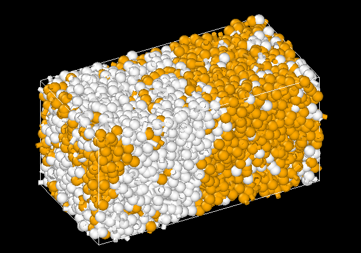

*N=5*

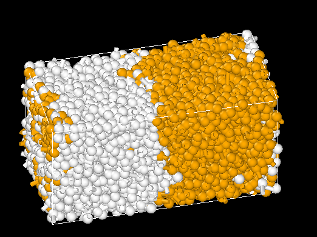

*N=10*

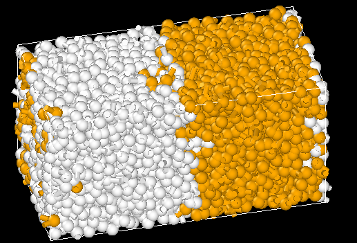

The Simulation and Ideal values don't have to agree as the ideal-chain result assumes independent bonds. As the simulated beads also have repellent properties, the chains can be expanded.

|  | N | delta_a | phi_A | err_phi | chi_N | err_chi_N | chi | chi_N_over_da | plateau_slope | mirror_check | blocks |
| --- | --- | --- | --- | --- | --- | --- | --- | --- | --- | --- | --- |
| 0 | 3 | 3.0 | 0.1413 | 0.0064 | 2.5153 | 0.0285 | 0.8384 | 0.8384 | -0.0028 | -0.0058 | 8 |
| 1 | 3 | 5.0 | 0.0141 | 0.0017 | 4.3697 | 0.1101 | 1.4566 | 0.8739 | 0.0004 | 0.0022 | 8 |
| 2 | 3 | 7.0 | 0.0011 | 0.0004 | 6.8111 | 0.3476 | 2.2704 | 0.9730 | -0.0001 | -0.0008 | 8 |
| 3 | 5 | 2.0 | 0.0743 | 0.0044 | 2.9625 | 0.0442 | 0.5925 | 1.4812 | -0.0058 | -0.0098 | 8 |
| 4 | 5 | 3.5 | 0.0062 | 0.0010 | 5.1402 | 0.1538 | 1.0280 | 1.4686 | 0.0000 | 0.0016 | 8 |
| 5 | 5 | 5.0 | 0.0008 | 0.0005 | 7.1209 | 0.6385 | 1.4242 | 1.4242 | -0.0001 | 0.0002 | 8 |
| 6 | 10 | 1.0 | 0.1314 | 0.0103 | 2.5621 | 0.0511 | 0.2562 | 2.5621 | -0.0115 | 0.0233 | 8 |
| 7 | 10 | 1.5 | 0.0178 | 0.0032 | 4.1589 | 0.1619 | 0.4159 | 2.7726 | -0.0004 | -0.0010 | 8 |
| 8 | 10 | 2.0 | 0.0099 | 0.0015 | 4.6955 | 0.1471 | 0.4696 | 2.3478 | 0.0002 | 0.0062 | 8 |

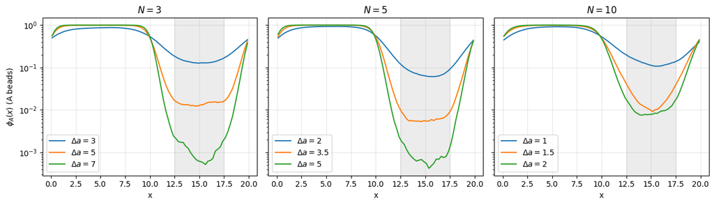

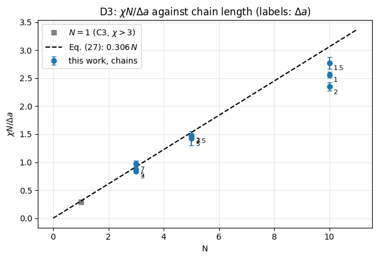

```
slope of chi N / Delta a against N through the origin, all 9 points (9): 0.266   (Eq. 27: 0.306)
slope of chi N / Delta a against N through the origin, points with chi N > 3 (6): 0.266   (Eq. 27: 0.306)
N = 1, mean of chi / Delta a for the three C3 runs with chi > 3: 0.288
```

```python
# D3: chi N for chains from the composition profiles, against Eq. (27)
import numpy as np, pandas as pd, matplotlib.pyplot as plt

RUNS = [(3, 3), (3, 5), (3, 7), (5, 2), (5, 3.5), (5, 5), (10, 1), (10, 1.5), (10, 2)]   # (N, Delta a)
USE_FROM = 20000                  # discard the first 20 000 steps, as in C2/C3
WINDOW = (12.5, 17.5)             # bulk of the B-rich phase, away from both interfaces (at x = 10 and 20)
EQ27 = 0.306                      # Groot-Warren Eq. (27): chi N / Delta a = 0.306 N

def chiN_of_phi(phi):             # Eq. (18) with N_A = N_B = N: chi N = ln[(1-phi)/phi] / (1-2 phi)
    return np.log((1 - phi) / phi) / (1 - 2 * phi)

def run_name(N, da):
    return f"D3_N{N}_da{da:g}"

rows, profiles = [], {}
for N, da in RUNS:
    p = pd.read_csv(f"data/{run_name(N, da)}_profile.csv")
    p["phi"] = p.rho_A / (p.rho_A + p.rho_B)          # A-bead fraction: the beads of A chains count as A
    q = p[p.step_end > USE_FROM]
    profiles[(N, da)] = q.groupby("x").phi.mean()
    win = q[(q.x > WINDOW[0]) & (q.x < WINDOW[1])]
    per_block = win.groupby("block").phi.mean()
    phi, dphi = per_block.mean(), per_block.std(ddof=1) / np.sqrt(len(per_block))
    chiN = chiN_of_phi(phi)
    dchiN = abs(chiN_of_phi(phi + dphi) - chiN_of_phi(phi - dphi)) / 2
    prof = win.groupby("x").phi.mean()
    slope = np.polyfit(prof.index, prof.values, 1)[0]        # flatness of the plateau, d(phi)/dx
    # the A-rich bulk (x = 2.5..7.5) must give the mirror image 1 - phi
    arich = q[(q.x > 2.5) & (q.x < 7.5)].groupby("block").phi.mean().mean()
    rows.append(dict(N=N, delta_a=da, phi_A=phi, err_phi=dphi, chi_N=chiN, err_chi_N=dchiN,
                     chi=chiN / N, chi_N_over_da=chiN / da, plateau_slope=slope,
                     mirror_check=arich + phi - 1, blocks=len(per_block)))
tab = pd.DataFrame(rows)
pd.set_option("display.width", 200)
display(tab.round(4))

# --- figure 1: the profiles, one panel per chain length
fig, axes = plt.subplots(1, 3, figsize=(13, 3.8), sharey=True)
for ax, N in zip(axes, (3, 5, 10)):
    for (n, da), prof in profiles.items():
        if n == N:
            ax.plot(prof.index, prof.values, label=f"$\\Delta a={da:g}$")
    ax.set(xlabel="x", title=f"$N={N}$", yscale="log")
    ax.axvspan(*WINDOW, color="gray", alpha=0.15)
    ax.grid(alpha=0.3); ax.legend()
axes[0].set_ylabel("$\\phi_A(x)$ (A beads)")
plt.tight_layout(); plt.show()

# --- figure 2: chi N / Delta a against N, with Eq. (27); N = 1 from the monomer runs of C3
mono = []
for a_ab in (39, 43, 47):                                  # the C3 runs with chi > 3
    p = pd.read_csv(f"data/C3_a{a_ab}_profile.csv"); p["phi"] = p.rho_A / (p.rho_A + p.rho_B)
    q = p[(p.step_end > USE_FROM) & (p.x > WINDOW[0]) & (p.x < WINDOW[1])]
    mono.append(chiN_of_phi(q.groupby("block").phi.mean().mean()) / (a_ab - 25))
fig, ax = plt.subplots(figsize=(6.5, 4.5))
ax.errorbar(tab.N, tab.chi_N_over_da, tab.err_chi_N / tab.delta_a, fmt="o", capsize=3, label="this work, chains")
for (N, da), y in zip(zip(tab.N, tab.delta_a), tab.chi_N_over_da):
    ax.annotate(f"{da:g}", (N, y), textcoords="offset points", xytext=(5, -9), fontsize=8)
ax.plot([1], [np.mean(mono)], "s", color="gray", label="$N=1$ (C3, $\\chi>3$)")
ns = np.linspace(0, 11, 20)
ax.plot(ns, EQ27 * ns, "k--", label="Eq. (27): $0.306\\,N$")
ax.set(xlabel="N", ylabel="$\\chi N/\\Delta a$", title="D3: $\\chi N/\\Delta a$ against chain length (labels: $\\Delta a$)")
ax.grid(alpha=0.3); ax.legend(); plt.tight_layout(); plt.show()

# slope of chi N / Delta a against N: through the origin, for all points and for the points with chi N > 3
for label, sel in (("all 9 points", tab.chi_N > 0), ("points with chi N > 3", tab.chi_N > 3)):
    t = tab[sel]
    k0 = np.sum(t.N * t.chi_N_over_da) / np.sum(t.N ** 2)
    print(f"slope of chi N / Delta a against N through the origin, {label} ({len(t)}): {k0:.3f}   (Eq. 27: {EQ27})")
print(f"N = 1, mean of chi / Delta a for the three C3 runs with chi > 3: {np.mean(mono):.3f}")
```

## Lessons learned

What would you do differently if you started over? What surprised you? What broke first in the conversion from MD to DPD, and how did you find it? (Standing questions in the oral, so write the honest version.)

*Lessons learned:*

- **What broke first.** The $g(r)$ normalisation: the first versions were not flat for the ideal gas (B2), which is why B2 exists. The next failure was in B1: our first energy-conservation data wandered by about 1% independent of $Δt$, which is the signature of a noise force that was still on, not of integration error. The $Δt$ scaling exposed it, and we regenerated the data with a script (`code/run_b1.sh`). Smaller slips were in the notebook: the B2 plot read an energy log with a similar file name instead of the $g(r)$ file.
- **What surprised us.** How well the results agree with the paper: $χ/Δa=0.29$ and the surface tension within 1% of Eq. (36) at large $Δa$. The control run alone (it only checks the zero) would not have confirmed the factor of two in $σs$. The $g(r)$ blocks are so close that their scatter is invisible on a normal plot.
- **What we would do differently.** (1) Write the analysis (profiles, pressure tensor, block output) once and use it for every run, instead of two composition-profile writers. (2) Keep every run as a script from the start, so that the build and run log is the script. (3) Keep the data that the notebook reads in `data/` from the beginning (the D2 cell reads trajectory files that are not handed in). (4) Digitise the published curves early. (5) Check that a cell reads the file it names.

## Hand-in

One zip per group, layout exactly:

```
<group>_A3.zip
├── A3.ipynb     this notebook, filled in and executed
│                (all outputs present; task cells untouched)
├── A3.html      python3 nb2html.py A3.ipynb
├── code/        all .c/.h + README.md; must build with
│                gcc -O3 *.c -o dpd -lm    (no binaries)
└── data/        every data file this notebook loads
```

Long runs are done in the terminal; record the exact commands in the *Build & run log* and let the notebook load the saved output from `data/`. Handed in executed, the notebook must open and display without rerunning anything.

**Before you submit,** check your own zip:

```
python3 check_my_submission.py <group>_A3.zip --release A3.ipynb
```

where `--release` is a freshly downloaded, unmodified `A3.ipynb`. It verifies the layout, that the task cells are untouched, that every cell has been executed, that your C code compiles, and that every path and link in the notebook is relative and present in the zip. Fix what it reports, then submit. Setting up the Python environment (`requirements.txt`, both helper scripts) is described on the Canvas page *Working on the assignments*.